# Step 1: Problem Description and Data

## Introduction to the Problem

This notebook addresses the Kaggle competition for disaster tweet classification (https://www.kaggle.com/c/nlp-getting-started/overview). The task is to predict which tweets are about real disasters and which ones are not.

The ability to automatically identify tweets about real disasters is valuable for emergency services, disaster response organizations, and news agencies. It can help filter through the noise of social media to find actionable information during emergencies, potentially saving lives and improving response times.

## Dataset Description

The dataset comes from the Kaggle competition "Natural Language Processing with Disaster Tweets" and consists of the following files:

- train.csv - the training set with 7,613 labeled tweets
- test.csv - the test set with 3,263 unlabeled tweets
- sample_submission.csv - a sample submission file in the correct format

Each sample in the train and test set has the following information:

- id - a unique identifier for each tweet
- text - the text of the tweet
- location - the location the tweet was sent from (may be blank)
- keyword - a particular keyword from the tweet (may be blank)
- target - in train.csv only, this denotes whether a tweet is about a real disaster (1) or not (0)

In this section, we will:

- Examine the structure of the data
- Analyze the size of the dataset
- Explore the features available
- Understand the distribution of the target variable

```python
# Import necessary libraries
import pandas as pd
import numpy as np
import matplotlib.pyplot as plt
import seaborn as sns

# Set visualization style
sns.set_style('whitegrid')
plt.style.use('fivethirtyeight')
```

```python
# Load the dataset
train_df = pd.read_csv('../data/train.csv')
test_df = pd.read_csv('../data/test.csv')

# Display basic information
print(f"Training set shape: {train_df.shape}")
print(f"Test set shape: {test_df.shape}")
```

```
Training set shape: (7613, 5)
Test set shape: (3263, 4)
```

```python
# Display the first few rows of the training data
train_df.head()
```

|  | id | keyword | location | text | target |
| --- | --- | --- | --- | --- | --- |
| 0 | 1 | NaN | NaN | Our Deeds are the Reason of this #earthquake M... | 1 |
| 1 | 4 | NaN | NaN | Forest fire near La Ronge Sask. Canada | 1 |
| 2 | 5 | NaN | NaN | All residents asked to 'shelter in place' are ... | 1 |
| 3 | 6 | NaN | NaN | 13,000 people receive #wildfires evacuation or... | 1 |
| 4 | 7 | NaN | NaN | Just got sent this photo from Ruby #Alaska as ... | 1 |

### Feature Description

Let's examine each feature in the dataset:

1. **id**: A unique identifier for each tweet in the dataset.
2. **text**: The actual content of the tweet that we'll analyze to determine if it's about a real disaster.
3. **location**: The location from which the tweet was sent. This may provide context about regional disasters but can be blank.
4. **keyword**: A particular keyword extracted from the tweet. This could be useful for identifying disaster-related content but may also be blank.
5. **target**: (Only in train.csv) The classification label - 1 if the tweet is about a real disaster, 0 if not.

```python
# Check for missing values
print("Missing values in training data:")
print(train_df.isnull().sum())

print("\nMissing values in test data:")
print(test_df.isnull().sum())

# Note: The high percentage of missing location data (~33%) suggests that this feature
# might have limited usefulness for our model. We'll need to consider this during feature engineering.
```

```
Missing values in training data:
id             0
keyword       61
location    2533
text           0
target         0
dtype: int64

Missing values in test data:
id             0
keyword       26
location    1105
text           0
dtype: int64
```

## Objective

The objective of this project is to build a machine learning model that can classify tweets into two categories:

1. Tweets about real disasters (target = 1)
2. Tweets that are not about real disasters (target = 0)

This is a binary classification problem in the domain of Natural Language Processing (NLP). Our goal is to develop a model that can accurately distinguish between tweets about real disasters and those that are not, which could be valuable for emergency response systems.

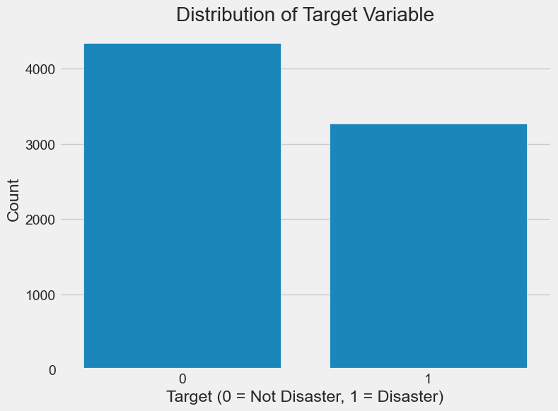

```
Percentage of non-disaster tweets (0): 57.03%
Percentage of disaster tweets (1): 42.97%
```

```python
# Examine the distribution of the target variable
if 'target' in train_df.columns:
    plt.figure(figsize=(8, 6))
    sns.countplot(x='target', data=train_df)
    plt.title('Distribution of Target Variable')
    plt.xlabel('Target (0 = Not Disaster, 1 = Disaster)')
    plt.ylabel('Count')
    plt.show()

    # Print the percentage of each class
    target_counts = train_df['target'].value_counts(normalize=True) * 100
    print(f"Percentage of non-disaster tweets (0): {target_counts[0]:.2f}%")
    print(f"Percentage of disaster tweets (1): {target_counts[1]:.2f}%")

# Note: This slight class imbalance (approximately 57% non-disaster, 43% disaster) is important
# to consider when designing our model and choosing evaluation metrics. We'll need to ensure
# our model doesn't simply predict the majority class and instead learns meaningful patterns.
```

## Summary

In this notebook, we have:

1. Introduced the problem of disaster tweet classification and its real-world importance
2. Described the dataset source, structure, and features in detail
3. Examined the distribution of the target variable and noted the slight class imbalance
4. Identified the objective of the project and its potential applications

## Next Steps

In the next notebook, we will:

1. Perform a more detailed exploratory data analysis to gain deeper insights into the data
2. Visualize patterns in the data through word clouds and other visualizations
3. Clean and preprocess the text data to prepare it for modeling
4. Develop a plan for modeling based on our insights from the EDA

These steps will help us build a strong foundation for our machine learning models and ensure we're making informed decisions throughout the project.

# Step 2: Exploratory Data Analysis (EDA)

In this notebook, we will perform exploratory data analysis on the disaster tweets dataset to gain insights into the data structure, patterns, and characteristics.

```python
# Import necessary libraries
import pandas as pd
import numpy as np
import matplotlib.pyplot as plt
import seaborn as sns
from wordcloud import WordCloud
import re
import nltk
from nltk.corpus import stopwords
from nltk.tokenize import word_tokenize
from nltk.stem import WordNetLemmatizer
from collections import Counter

# Set visualization style
sns.set_style('whitegrid')
plt.style.use('fivethirtyeight')

# Download NLTK resources
nltk.download('punkt')
nltk.download('stopwords')
nltk.download('wordnet')
```

```
True
```

## 1. Inspect Data

Let's load and examine the structure of our dataset.

```python
# Load the dataset
train_df = pd.read_csv('../data/train.csv')
test_df = pd.read_csv('../data/test.csv')

# Display basic information
print(f"Training set shape: {train_df.shape}")
print(f"Test set shape: {test_df.shape}")

# Display the first few rows
train_df.head()
```

```
Training set shape: (7613, 5)
Test set shape: (3263, 4)
```

|  | id | keyword | location | text | target |
| --- | --- | --- | --- | --- | --- |
| 0 | 1 | NaN | NaN | Our Deeds are the Reason of this #earthquake M... | 1 |
| 1 | 4 | NaN | NaN | Forest fire near La Ronge Sask. Canada | 1 |
| 2 | 5 | NaN | NaN | All residents asked to 'shelter in place' are ... | 1 |
| 3 | 6 | NaN | NaN | 13,000 people receive #wildfires evacuation or... | 1 |
| 4 | 7 | NaN | NaN | Just got sent this photo from Ruby #Alaska as ... | 1 |

```python
# Check data types and missing values
train_df.info()
```

```
<class 'pandas.core.frame.DataFrame'>
RangeIndex: 7613 entries, 0 to 7612
Data columns (total 5 columns):
 #   Column    Non-Null Count  Dtype
---  ------    --------------  -----
 0   id        7613 non-null   int64
 1   keyword   7552 non-null   object
 2   location  5080 non-null   object
 3   text      7613 non-null   object
 4   target    7613 non-null   int64
dtypes: int64(2), object(3)
memory usage: 297.5+ KB
```

```python
# Statistical summary of numerical columns
train_df.describe()
```

|  | id | target |
| --- | --- | --- |
| count | 7613.000000 | 7613.00000 |
| mean | 5441.934848 | 0.42966 |
| std | 3137.116090 | 0.49506 |
| min | 1.000000 | 0.00000 |
| 25% | 2734.000000 | 0.00000 |
| 50% | 5408.000000 | 0.00000 |
| 75% | 8146.000000 | 1.00000 |
| max | 10873.000000 | 1.00000 |

## 2. Visualize Data

Let's create various visualizations to better understand our data.

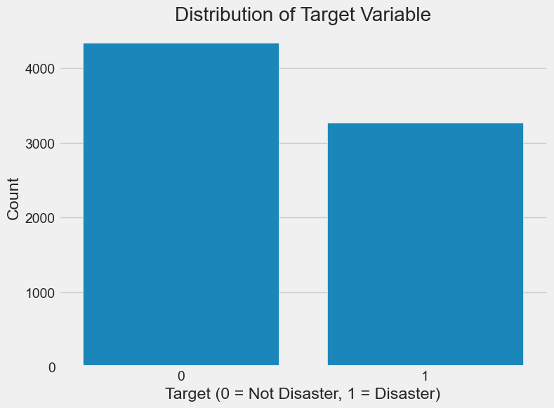

```
Percentage of non-disaster tweets (0): 57.03%
Percentage of disaster tweets (1): 42.97%
```

```python
# Distribution of target variable
plt.figure(figsize=(8, 6))
sns.countplot(x='target', data=train_df)
plt.title('Distribution of Target Variable')
plt.xlabel('Target (0 = Not Disaster, 1 = Disaster)')
plt.ylabel('Count')
plt.show()

# Print the percentage of each class
target_counts = train_df['target'].value_counts(normalize=True) * 100
print(f"Percentage of non-disaster tweets (0): {target_counts[0]:.2f}%")
print(f"Percentage of disaster tweets (1): {target_counts[1]:.2f}%")
```

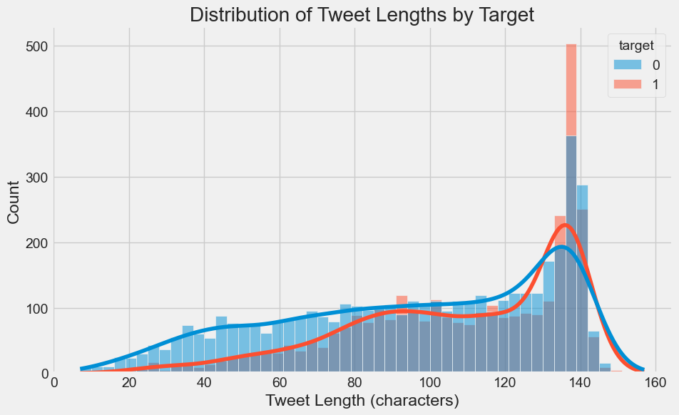

| target | count | mean | std | min | 25% | 50% | 75% | max |
| --- | --- | --- | --- | --- | --- | --- | --- | --- |
| 0 | 4342.0 | 95.706817 | 35.885924 | 7.0 | 68.0 | 101.0 | 130.0 | 157.0 |
| 1 | 3271.0 | 108.113421 | 29.309854 | 14.0 | 88.0 | 115.0 | 136.0 | 151.0 |

```python
# Analyze tweet length
train_df['tweet_length'] = train_df['text'].apply(len)

plt.figure(figsize=(10, 6))
sns.histplot(data=train_df, x='tweet_length', hue='target', bins=50, kde=True)
plt.title('Distribution of Tweet Lengths by Target')
plt.xlabel('Tweet Length (characters)')
plt.ylabel('Count')
plt.show()

# Statistical summary of tweet lengths by target
train_df.groupby('target')['tweet_length'].describe()
```

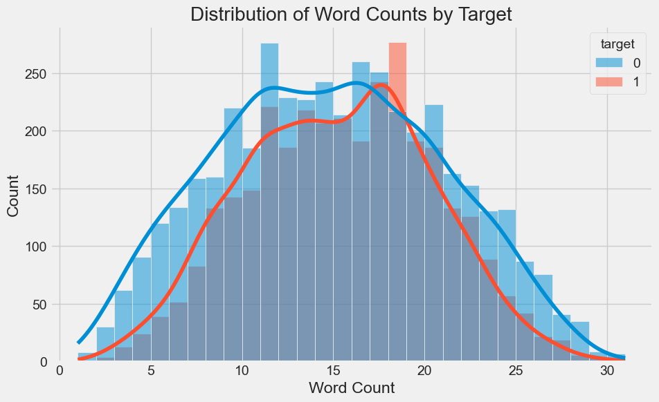

| target | count | mean | std | min | 25% | 50% | 75% | max |
| --- | --- | --- | --- | --- | --- | --- | --- | --- |
| 0 | 4342.0 | 14.704744 | 6.161564 | 1.0 | 10.0 | 15.0 | 19.0 | 31.0 |
| 1 | 3271.0 | 15.167533 | 5.096806 | 2.0 | 11.0 | 15.0 | 19.0 | 30.0 |

```python
# Word count analysis
train_df['word_count'] = train_df['text'].apply(lambda x: len(str(x).split()))

plt.figure(figsize=(10, 6))
sns.histplot(data=train_df, x='word_count', hue='target', bins=30, kde=True)
plt.title('Distribution of Word Counts by Target')
plt.xlabel('Word Count')
plt.ylabel('Count')
plt.show()

# Statistical summary of word counts by target
train_df.groupby('target')['word_count'].describe()
```

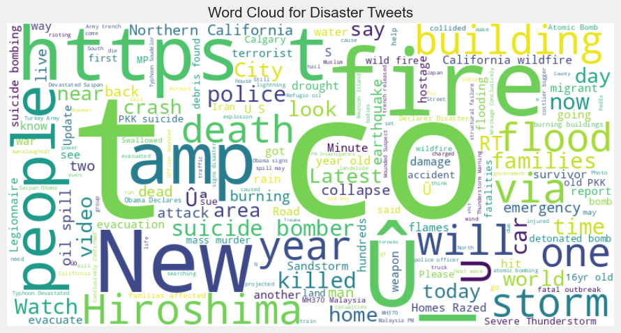

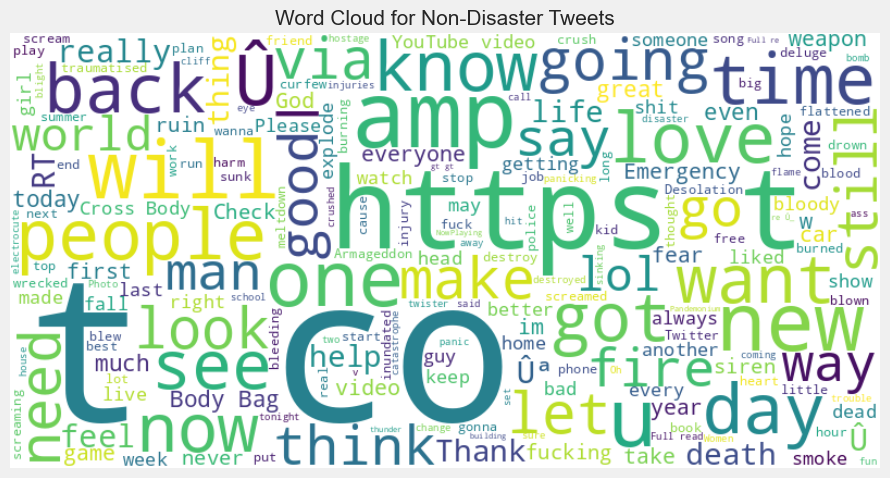

```python
# Function to create word clouds
def create_wordcloud(text, title):
    wordcloud = WordCloud(width=800, height=400, background_color='white',
                          max_words=200, contour_width=3, contour_color='steelblue').generate(text)

    plt.figure(figsize=(10, 6))
    plt.imshow(wordcloud, interpolation='bilinear')
    plt.title(title, fontsize=15)
    plt.axis('off')
    plt.show()

# Create word clouds for disaster and non-disaster tweets
disaster_tweets = ' '.join(train_df[train_df['target'] == 1]['text'])
non_disaster_tweets = ' '.join(train_df[train_df['target'] == 0]['text'])

create_wordcloud(disaster_tweets, 'Word Cloud for Disaster Tweets')
create_wordcloud(non_disaster_tweets, 'Word Cloud for Non-Disaster Tweets')
```

## 3. Clean Data

Let's preprocess the text data to prepare it for analysis and modeling.

```python
# Function to clean text
def clean_text(text):
    if isinstance(text, str):
        # Convert to lowercase
        text = text.lower()

        # Remove URLs
        text = re.sub(r'http\S+|www\S+|https\S+', '', text, flags=re.MULTILINE)

        # Remove user mentions
        text = re.sub(r'@\w+', '', text)

        # Remove hashtags
        text = re.sub(r'#\w+', '', text)

        # Remove special characters and numbers
        text = re.sub(r'[^\w\s]', '', text)
        text = re.sub(r'\d+', '', text)

        # Remove extra whitespace
        text = re.sub(r'\s+', ' ', text).strip()

        return text
    else:
        return ''

# Apply text cleaning
train_df['cleaned_text'] = train_df['text'].apply(clean_text)
test_df['cleaned_text'] = test_df['text'].apply(clean_text)

# Display examples of original and cleaned text
pd.set_option('display.max_colwidth', None)
train_df[['text', 'cleaned_text']].head()
```

|  | text | cleaned_text |
| --- | --- | --- |
| 0 | Our Deeds are the Reason of this #earthquake May ALLAH Forgive us all | our deeds are the reason of this may allah forgive us all |
| 1 | Forest fire near La Ronge Sask. Canada | forest fire near la ronge sask canada |
| 2 | All residents asked to 'shelter in place' are being notified by officers. No other evacuation or shelter in place orders are expected | all residents asked to shelter in place are being notified by officers no other evacuation or shelter in place orders are expected |
| 3 | 13,000 people receive #wildfires evacuation orders in California | people receive evacuation orders in california |
| 4 | Just got sent this photo from Ruby #Alaska as smoke from #wildfires pours into a school | just got sent this photo from ruby as smoke from pours into a school |

```python
# Function to remove stopwords and lemmatize
def preprocess_text(text):
    if isinstance(text, str) and text.strip():
        # Tokenize
        tokens = word_tokenize(text)

        # Remove stopwords
        stop_words = set(stopwords.words('english'))
        tokens = [word for word in tokens if word not in stop_words]

        # Lemmatize
        lemmatizer = WordNetLemmatizer()
        tokens = [lemmatizer.lemmatize(word) for word in tokens]

        return ' '.join(tokens)
    else:
        return ''

# Apply preprocessing
train_df['processed_text'] = train_df['cleaned_text'].apply(preprocess_text)
test_df['processed_text'] = test_df['cleaned_text'].apply(preprocess_text)

# Display examples of cleaned and processed text
train_df[['cleaned_text', 'processed_text']].head()
```

|  | cleaned_text | processed_text |
| --- | --- | --- |
| 0 | our deeds are the reason of this may allah forgive us all | deed reason may allah forgive u |
| 1 | forest fire near la ronge sask canada | forest fire near la ronge sask canada |
| 2 | all residents asked to shelter in place are being notified by officers no other evacuation or shelter in place orders are expected | resident asked shelter place notified officer evacuation shelter place order expected |
| 3 | people receive evacuation orders in california | people receive evacuation order california |
| 4 | just got sent this photo from ruby as smoke from pours into a school | got sent photo ruby smoke pours school |

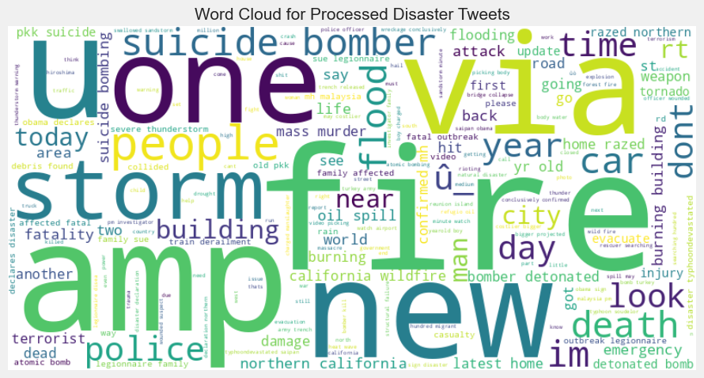

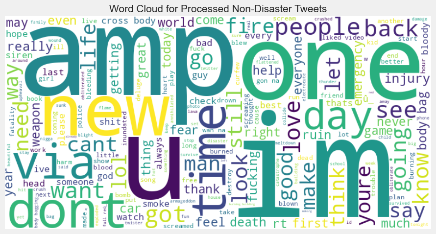

```python
# Create word clouds for processed disaster and non-disaster tweets
processed_disaster_tweets = ' '.join(train_df[train_df['target'] == 1]['processed_text'])
processed_non_disaster_tweets = ' '.join(train_df[train_df['target'] == 0]['processed_text'])

create_wordcloud(processed_disaster_tweets, 'Word Cloud for Processed Disaster Tweets')
create_wordcloud(processed_non_disaster_tweets, 'Word Cloud for Processed Non-Disaster Tweets')
```

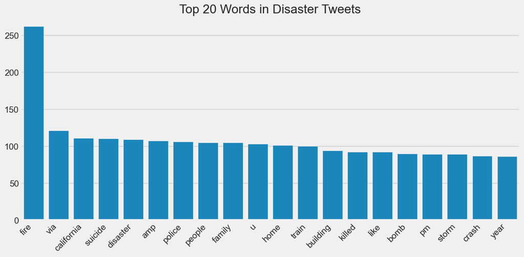

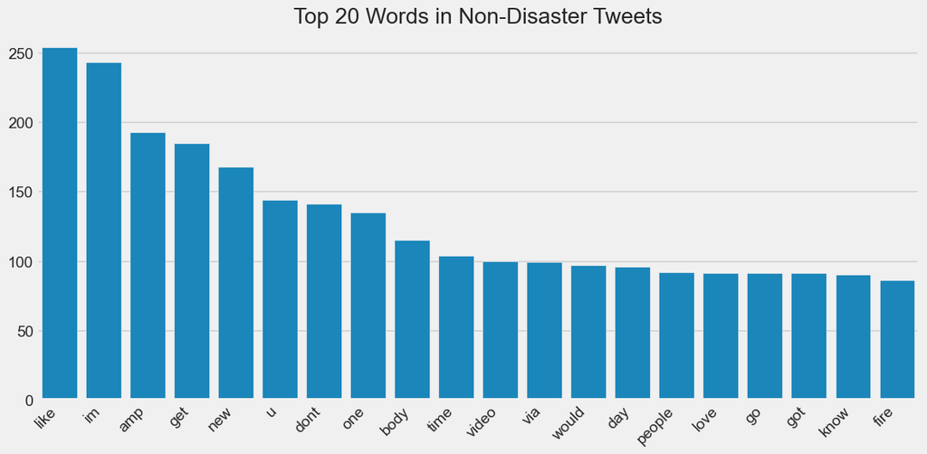

```python
# Analyze most common words in disaster and non-disaster tweets
def get_top_words(text, n=20):
    words = ' '.join(text).split()
    word_counts = Counter(words)
    return word_counts.most_common(n)

# Get top words for each class
disaster_top_words = get_top_words(train_df[train_df['target'] == 1]['processed_text'])
non_disaster_top_words = get_top_words(train_df[train_df['target'] == 0]['processed_text'])

# Plot top words for disaster tweets
plt.figure(figsize=(12, 6))
words, counts = zip(*disaster_top_words)
sns.barplot(x=list(words), y=list(counts))
plt.title('Top 20 Words in Disaster Tweets')
plt.xticks(rotation=45, ha='right')
plt.tight_layout()
plt.show()

# Plot top words for non-disaster tweets
plt.figure(figsize=(12, 6))
words, counts = zip(*non_disaster_top_words)
sns.barplot(x=list(words), y=list(counts))
plt.title('Top 20 Words in Non-Disaster Tweets')
plt.xticks(rotation=45, ha='right')
plt.tight_layout()
plt.show()
```

## 4. Plan of Analysis

Based on our exploratory data analysis, we can now define our preprocessing and modeling approach.

### Preprocessing Strategy

Based on our EDA, we will implement the following preprocessing steps:

1. **Text Cleaning**:
   - Convert to lowercase
   - Remove URLs, user mentions, and hashtags
   - Remove special characters and numbers
   - Remove extra whitespace
2. **Text Preprocessing**:
   - Tokenization
   - Stopword removal
   - Lemmatization
3. **Feature Engineering**:
   - Text vectorization (to be implemented in the modeling notebook)
   - Potentially extract additional features from text (e.g., tweet length, presence of specific keywords)

### Modeling Approach

Based on our understanding of the data, we will consider the following modeling approaches:

1. **Text Vectorization**:
   - TF-IDF
   - Word embeddings (Word2Vec, GloVe)
2. **Model Architecture**:
   - Recurrent Neural Networks (RNNs)
   - Long Short-Term Memory (LSTM)
   - Gated Recurrent Units (GRU)
   - Bidirectional RNNs
3. **Evaluation Metrics**:
   - Accuracy
   - Precision
   - Recall
   - F1-score
   - Confusion matrix

## Summary

In this notebook, we have:

1. Inspected the dataset structure and characteristics
2. Visualized the data through various plots and word clouds
3. Cleaned and preprocessed the text data
4. Developed a plan for further analysis and modeling

Next, we will implement our model architecture based on the insights gained from this exploratory data analysis.

# Step 3: Model Architecture

In this notebook, we will design and implement the model architecture for our disaster tweet classification task. We'll explore different text vectorization methods and neural network architectures to build an effective classifier.

```python
# Import necessary libraries
import pandas as pd
import numpy as np
import matplotlib.pyplot as plt
import seaborn as sns
import re
import nltk
from nltk.corpus import stopwords
from nltk.tokenize import word_tokenize
from nltk.stem import WordNetLemmatizer

# Download NLTK resources
nltk.download('punkt')
nltk.download('stopwords')
nltk.download('wordnet')

# For text processing and vectorization
from sklearn.feature_extraction.text import TfidfVectorizer
from sklearn.model_selection import train_test_split
from sklearn.preprocessing import LabelEncoder
from tensorflow.keras.preprocessing.text import Tokenizer
from tensorflow.keras.preprocessing.sequence import pad_sequences

# For model building
import tensorflow as tf
from tensorflow.keras.models import Sequential, Model
from tensorflow.keras.layers import Dense, LSTM, GRU, Bidirectional, Embedding, Dropout, Input, GlobalMaxPooling1D, Conv1D, MaxPooling1D, Concatenate
from tensorflow.keras.callbacks import EarlyStopping, ModelCheckpoint
from tensorflow.keras.optimizers import Adam

# For visualization
import matplotlib.pyplot as plt
import seaborn as sns

# Set random seed for reproducibility
np.random.seed(42)
tf.random.set_seed(42)
```

## 1. Load and Preprocess Data

```python
# Load the dataset
train_df = pd.read_csv('../data/train.csv')
test_df = pd.read_csv('../data/test.csv')

# Display basic information
print(f"Training set shape: {train_df.shape}")
print(f"Test set shape: {test_df.shape}")
```

```
Training set shape: (7613, 5)
Test set shape: (3263, 4)
```

```python
# Function to clean text (same as in EDA notebook)
def clean_text(text):
    if isinstance(text, str):
        # Convert to lowercase
        text = text.lower()

        # Remove URLs
        text = re.sub(r'http\S+|www\S+|https\S+', '', text, flags=re.MULTILINE)

        # Remove user mentions
        text = re.sub(r'@\w+', '', text)

        # Remove hashtags
        text = re.sub(r'#\w+', '', text)

        # Remove special characters and numbers
        text = re.sub(r'[^\w\s]', '', text)
        text = re.sub(r'\d+', '', text)

        # Remove extra whitespace
        text = re.sub(r'\s+', ' ', text).strip()

        return text
    else:
        return ''

# Function to preprocess text (same as in EDA notebook)
def preprocess_text(text):
    if isinstance(text, str) and text.strip():
        # Tokenize
        tokens = word_tokenize(text)

        # Remove stopwords
        stop_words = set(stopwords.words('english'))
        tokens = [word for word in tokens if word not in stop_words]

        # Lemmatize
        lemmatizer = WordNetLemmatizer()
        tokens = [lemmatizer.lemmatize(word) for word in tokens]

        return ' '.join(tokens)
    else:
        return ''

# Apply text cleaning and preprocessing
train_df['cleaned_text'] = train_df['text'].apply(clean_text)
train_df['processed_text'] = train_df['cleaned_text'].apply(preprocess_text)

test_df['cleaned_text'] = test_df['text'].apply(clean_text)
test_df['processed_text'] = test_df['cleaned_text'].apply(preprocess_text)

# Display examples
train_df[['text', 'processed_text', 'target']].head()
```

|  | text | processed_text | target |
| --- | --- | --- | --- |
| 0 | Our Deeds are the Reason of this #earthquake M... | deed reason may allah forgive u | 1 |
| 1 | Forest fire near La Ronge Sask. Canada | forest fire near la ronge sask canada | 1 |
| 2 | All residents asked to 'shelter in place' are ... | resident asked shelter place notified officer ... | 1 |
| 3 | 13,000 people receive #wildfires evacuation or... | people receive evacuation order california | 1 |
| 4 | Just got sent this photo from Ruby #Alaska as ... | got sent photo ruby smoke pours school | 1 |

```python
# Split the data into training and validation sets
X_train, X_val, y_train, y_val = train_test_split(
    train_df['processed_text'],
    train_df['target'],
    test_size=0.2,
    random_state=42,
    stratify=train_df['target']
)

print(f"Training set size: {X_train.shape[0]}")
print(f"Validation set size: {X_val.shape[0]}")
```

```
Training set size: 6090
Validation set size: 1523
```

## 2. Text Vectorization

We'll explore different text vectorization methods to convert our text data into numerical representations that can be used by our models.

### 2.1 TF-IDF Vectorization

TF-IDF (Term Frequency-Inverse Document Frequency) is a statistical measure that evaluates how relevant a word is to a document in a collection of documents. It increases proportionally to the number of times a word appears in the document but is offset by the frequency of the word in the corpus.

```python
# Initialize TF-IDF Vectorizer
tfidf_vectorizer = TfidfVectorizer(max_features=5000)

# Fit and transform the training data
X_train_tfidf = tfidf_vectorizer.fit_transform(X_train)

# Transform the validation data
X_val_tfidf = tfidf_vectorizer.transform(X_val)

# Transform the test data
X_test_tfidf = tfidf_vectorizer.transform(test_df['processed_text'])

print(f"TF-IDF training set shape: {X_train_tfidf.shape}")
print(f"TF-IDF validation set shape: {X_val_tfidf.shape}")
print(f"TF-IDF test set shape: {X_test_tfidf.shape}")
```

```
TF-IDF training set shape: (6090, 5000)
TF-IDF validation set shape: (1523, 5000)
TF-IDF test set shape: (3263, 5000)
```

### 2.2 Tokenization and Sequence Padding

For neural network models, we need to tokenize the text and convert it to sequences of integers, then pad these sequences to ensure they all have the same length.

```python
# Initialize tokenizer
max_words = 10000  # Maximum number of words to keep
tokenizer = Tokenizer(num_words=max_words)

# Fit the tokenizer on the training data
tokenizer.fit_on_texts(X_train)

# Convert text to sequences
X_train_seq = tokenizer.texts_to_sequences(X_train)
X_val_seq = tokenizer.texts_to_sequences(X_val)
X_test_seq = tokenizer.texts_to_sequences(test_df['processed_text'])

# Get the word index
word_index = tokenizer.word_index
print(f"Number of unique words: {len(word_index)}")

# Determine the maximum sequence length
max_len = max([len(seq) for seq in X_train_seq])
print(f"Maximum sequence length: {max_len}")

# Choose a reasonable sequence length (e.g., 95th percentile)
seq_lengths = [len(seq) for seq in X_train_seq]
reasonable_len = int(np.percentile(seq_lengths, 95))
print(f"95th percentile sequence length: {reasonable_len}")

# Pad sequences to ensure uniform length
maxlen = min(reasonable_len, 50)  # Cap at 50 tokens for efficiency
X_train_pad = pad_sequences(X_train_seq, maxlen=maxlen, padding='post', truncating='post')
X_val_pad = pad_sequences(X_val_seq, maxlen=maxlen, padding='post', truncating='post')
X_test_pad = pad_sequences(X_test_seq, maxlen=maxlen, padding='post', truncating='post')

print(f"Padded training set shape: {X_train_pad.shape}")
print(f"Padded validation set shape: {X_val_pad.shape}")
print(f"Padded test set shape: {X_test_pad.shape}")
```

```
Number of unique words: 11042
Maximum sequence length: 23
95th percentile sequence length: 14
Padded training set shape: (6090, 14)
Padded validation set shape: (1523, 14)
Padded test set shape: (3263, 14)
```

### 2.3 Word Embeddings

Word embeddings are dense vector representations of words that capture semantic relationships. We'll use pre-trained GloVe embeddings for our models.

```python
# Download GloVe embeddings if not already downloaded
import os
import requests
from zipfile import ZipFile

# Create a directory for embeddings if it doesn't exist
embeddings_dir = '../data/embeddings'
os.makedirs(embeddings_dir, exist_ok=True)

# Path to GloVe embeddings file
glove_file = os.path.join(embeddings_dir, 'glove.6B.100d.txt')

# Download GloVe embeddings if they don't exist
if not os.path.exists(glove_file):
    print("Downloading GloVe embeddings...")
    # URL for GloVe embeddings
    glove_url = 'https://nlp.stanford.edu/data/glove.6B.zip'

    # Download the zip file
    response = requests.get(glove_url)
    zip_path = os.path.join(embeddings_dir, 'glove.6B.zip')

    with open(zip_path, 'wb') as f:
        f.write(response.content)

    # Extract the zip file
    with ZipFile(zip_path, 'r') as zip_ref:
        zip_ref.extractall(embeddings_dir)

    # Remove the zip file
    os.remove(zip_path)
    print("GloVe embeddings downloaded and extracted.")
else:
    print("GloVe embeddings already exist.")
```

```
GloVe embeddings already exist.
```

```python
# Load GloVe embeddings
embedding_dim = 100  # Dimension of the GloVe embeddings
embeddings_index = {}

# Load GloVe embeddings
with open(glove_file, encoding='utf-8') as f:
    for line in f:
        values = line.split()
        word = values[0]
        coefs = np.asarray(values[1:], dtype='float32')
        embeddings_index[word] = coefs

print(f"Found {len(embeddings_index)} word vectors.")

# Create an embedding matrix for our vocabulary
embedding_matrix = np.zeros((len(word_index) + 1, embedding_dim))
for word, i in word_index.items():
    embedding_vector = embeddings_index.get(word)
    if embedding_vector is not None:
        embedding_matrix[i] = embedding_vector

# Calculate the percentage of words in our vocabulary that are found in GloVe
words_found = sum(1 for word in word_index if word in embeddings_index)
print(f"Found embeddings for {words_found / len(word_index) * 100:.2f}% of vocabulary.")
```

```
Found 400000 word vectors.
Found embeddings for 82.89% of vocabulary.
```

## 3. Model Architecture

We'll implement several neural network architectures for text classification, including RNNs, LSTMs, GRUs, and Bidirectional RNNs.

### 3.1 Simple RNN Model

```python
def build_simple_rnn_model(use_pretrained_embeddings=True):
    model = Sequential()

    if use_pretrained_embeddings:
        model.add(Embedding(len(word_index) + 1, embedding_dim,
                           weights=[embedding_matrix],
                           input_length=maxlen,
                           trainable=False))
    else:
        model.add(Embedding(max_words, 100, input_length=maxlen))

    model.add(tf.keras.layers.SimpleRNN(64, return_sequences=False))
    model.add(Dense(32, activation='relu'))
    model.add(Dropout(0.5))
    model.add(Dense(1, activation='sigmoid'))

    model.compile(optimizer=Adam(learning_rate=0.001),
                  loss='binary_crossentropy',
                  metrics=['accuracy'])

    return model

# Create the model with pre-trained embeddings
simple_rnn_model = build_simple_rnn_model(use_pretrained_embeddings=True)
simple_rnn_model.summary()
```

```
Model: "sequential"
```

```
┏━━━━━━━━━━━━━━━━━━━━━━━━━━━━━━━━━┳━━━━━━━━━━━━━━━━━━━━━━━━┳━━━━━━━━━━━━━━━┓
┃ Layer (type)                    ┃ Output Shape           ┃       Param # ┃
┡━━━━━━━━━━━━━━━━━━━━━━━━━━━━━━━━━╇━━━━━━━━━━━━━━━━━━━━━━━━╇━━━━━━━━━━━━━━━┩
│ embedding (Embedding)           │ ?                      │     1,104,300 │
├─────────────────────────────────┼────────────────────────┼───────────────┤
│ simple_rnn (SimpleRNN)          │ ?                      │   0 (unbuilt) │
├─────────────────────────────────┼────────────────────────┼───────────────┤
│ dense (Dense)                   │ ?                      │   0 (unbuilt) │
├─────────────────────────────────┼────────────────────────┼───────────────┤
│ dropout (Dropout)               │ ?                      │             0 │
├─────────────────────────────────┼────────────────────────┼───────────────┤
│ dense_1 (Dense)                 │ ?                      │   0 (unbuilt) │
└─────────────────────────────────┴────────────────────────┴───────────────┘
```

```
 Total params: 1,104,300 (4.21 MB)
```

```
 Trainable params: 0 (0.00 B)
```

```
 Non-trainable params: 1,104,300 (4.21 MB)
```

### 3.2 LSTM Model

```python
def build_lstm_model(use_pretrained_embeddings=True):
    model = Sequential()

    if use_pretrained_embeddings:
        model.add(Embedding(len(word_index) + 1, embedding_dim,
                           weights=[embedding_matrix],
                           input_length=maxlen,
                           trainable=False))
    else:
        model.add(Embedding(max_words, 100, input_length=maxlen))

    model.add(LSTM(64, return_sequences=False))
    model.add(Dense(32, activation='relu'))
    model.add(Dropout(0.5))
    model.add(Dense(1, activation='sigmoid'))

    model.compile(optimizer=Adam(learning_rate=0.001),
                  loss='binary_crossentropy',
                  metrics=['accuracy'])

    return model

# Create the model with pre-trained embeddings
lstm_model = build_lstm_model(use_pretrained_embeddings=True)
lstm_model.summary()
```

```
Model: "sequential_1"
```

```
┏━━━━━━━━━━━━━━━━━━━━━━━━━━━━━━━━━┳━━━━━━━━━━━━━━━━━━━━━━━━┳━━━━━━━━━━━━━━━┓
┃ Layer (type)                    ┃ Output Shape           ┃       Param # ┃
┡━━━━━━━━━━━━━━━━━━━━━━━━━━━━━━━━━╇━━━━━━━━━━━━━━━━━━━━━━━━╇━━━━━━━━━━━━━━━┩
│ embedding_1 (Embedding)         │ ?                      │     1,104,300 │
├─────────────────────────────────┼────────────────────────┼───────────────┤
│ lstm (LSTM)                     │ ?                      │   0 (unbuilt) │
├─────────────────────────────────┼────────────────────────┼───────────────┤
│ dense_2 (Dense)                 │ ?                      │   0 (unbuilt) │
├─────────────────────────────────┼────────────────────────┼───────────────┤
│ dropout_1 (Dropout)             │ ?                      │             0 │
├─────────────────────────────────┼────────────────────────┼───────────────┤
│ dense_3 (Dense)                 │ ?                      │   0 (unbuilt) │
└─────────────────────────────────┴────────────────────────┴───────────────┘
```

```
 Total params: 1,104,300 (4.21 MB)
```

```
 Trainable params: 0 (0.00 B)
```

```
 Non-trainable params: 1,104,300 (4.21 MB)
```

### 3.3 GRU Model

```python
def build_gru_model(use_pretrained_embeddings=True):
    model = Sequential()

    if use_pretrained_embeddings:
        model.add(Embedding(len(word_index) + 1, embedding_dim,
                           weights=[embedding_matrix],
                           input_length=maxlen,
                           trainable=False))
    else:
        model.add(Embedding(max_words, 100, input_length=maxlen))

    model.add(GRU(64, return_sequences=False))
    model.add(Dense(32, activation='relu'))
    model.add(Dropout(0.5))
    model.add(Dense(1, activation='sigmoid'))

    model.compile(optimizer=Adam(learning_rate=0.001),
                  loss='binary_crossentropy',
                  metrics=['accuracy'])

    return model

# Create the model with pre-trained embeddings
gru_model = build_gru_model(use_pretrained_embeddings=True)
gru_model.summary()
```

```
Model: "sequential_2"
```

```
┏━━━━━━━━━━━━━━━━━━━━━━━━━━━━━━━━━┳━━━━━━━━━━━━━━━━━━━━━━━━┳━━━━━━━━━━━━━━━┓
┃ Layer (type)                    ┃ Output Shape           ┃       Param # ┃
┡━━━━━━━━━━━━━━━━━━━━━━━━━━━━━━━━━╇━━━━━━━━━━━━━━━━━━━━━━━━╇━━━━━━━━━━━━━━━┩
│ embedding_2 (Embedding)         │ ?                      │     1,104,300 │
├─────────────────────────────────┼────────────────────────┼───────────────┤
│ gru (GRU)                       │ ?                      │   0 (unbuilt) │
├─────────────────────────────────┼────────────────────────┼───────────────┤
│ dense_4 (Dense)                 │ ?                      │   0 (unbuilt) │
├─────────────────────────────────┼────────────────────────┼───────────────┤
│ dropout_2 (Dropout)             │ ?                      │             0 │
├─────────────────────────────────┼────────────────────────┼───────────────┤
│ dense_5 (Dense)                 │ ?                      │   0 (unbuilt) │
└─────────────────────────────────┴────────────────────────┴───────────────┘
```

```
 Total params: 1,104,300 (4.21 MB)
```

```
 Trainable params: 0 (0.00 B)
```

```
 Non-trainable params: 1,104,300 (4.21 MB)
```

### 3.4 Bidirectional LSTM Model

```python
def build_bidirectional_lstm_model(use_pretrained_embeddings=True):
    model = Sequential()

    if use_pretrained_embeddings:
        model.add(Embedding(len(word_index) + 1, embedding_dim,
                           weights=[embedding_matrix],
                           input_length=maxlen,
                           trainable=False))
    else:
        model.add(Embedding(max_words, 100, input_length=maxlen))

    model.add(Bidirectional(LSTM(64, return_sequences=False)))
    model.add(Dense(32, activation='relu'))
    model.add(Dropout(0.5))
    model.add(Dense(1, activation='sigmoid'))

    model.compile(optimizer=Adam(learning_rate=0.001),
                  loss='binary_crossentropy',
                  metrics=['accuracy'])

    return model

# Create the model with pre-trained embeddings
bidirectional_lstm_model = build_bidirectional_lstm_model(use_pretrained_embeddings=True)
bidirectional_lstm_model.summary()
```

```
Model: "sequential_3"
```

```
┏━━━━━━━━━━━━━━━━━━━━━━━━━━━━━━━━━┳━━━━━━━━━━━━━━━━━━━━━━━━┳━━━━━━━━━━━━━━━┓
┃ Layer (type)                    ┃ Output Shape           ┃       Param # ┃
┡━━━━━━━━━━━━━━━━━━━━━━━━━━━━━━━━━╇━━━━━━━━━━━━━━━━━━━━━━━━╇━━━━━━━━━━━━━━━┩
│ embedding_3 (Embedding)         │ ?                      │     1,104,300 │
├─────────────────────────────────┼────────────────────────┼───────────────┤
│ bidirectional (Bidirectional)   │ ?                      │   0 (unbuilt) │
├─────────────────────────────────┼────────────────────────┼───────────────┤
│ dense_6 (Dense)                 │ ?                      │   0 (unbuilt) │
├─────────────────────────────────┼────────────────────────┼───────────────┤
│ dropout_3 (Dropout)             │ ?                      │             0 │
├─────────────────────────────────┼────────────────────────┼───────────────┤
│ dense_7 (Dense)                 │ ?                      │   0 (unbuilt) │
└─────────────────────────────────┴────────────────────────┴───────────────┘
```

```
 Total params: 1,104,300 (4.21 MB)
```

```
 Trainable params: 0 (0.00 B)
```

```
 Non-trainable params: 1,104,300 (4.21 MB)
```

### 3.5 CNN-LSTM Model

Combining Convolutional Neural Networks (CNNs) with LSTMs can be effective for text classification. CNNs can capture local patterns while LSTMs capture sequential dependencies.

```python
def build_cnn_lstm_model(use_pretrained_embeddings=True):
    model = Sequential()

    if use_pretrained_embeddings:
        model.add(Embedding(len(word_index) + 1, embedding_dim,
                           weights=[embedding_matrix],
                           input_length=maxlen,
                           trainable=False))
    else:
        model.add(Embedding(max_words, 100, input_length=maxlen))

    model.add(Conv1D(128, 5, activation='relu'))
    model.add(MaxPooling1D(5))
    model.add(LSTM(64, return_sequences=False))
    model.add(Dense(32, activation='relu'))
    model.add(Dropout(0.5))
    model.add(Dense(1, activation='sigmoid'))

    model.compile(optimizer=Adam(learning_rate=0.001),
                  loss='binary_crossentropy',
                  metrics=['accuracy'])

    return model

# Create the model with pre-trained embeddings
cnn_lstm_model = build_cnn_lstm_model(use_pretrained_embeddings=True)
cnn_lstm_model.summary()
```

```
Model: "sequential_4"
```

```
┏━━━━━━━━━━━━━━━━━━━━━━━━━━━━━━━━━┳━━━━━━━━━━━━━━━━━━━━━━━━┳━━━━━━━━━━━━━━━┓
┃ Layer (type)                    ┃ Output Shape           ┃       Param # ┃
┡━━━━━━━━━━━━━━━━━━━━━━━━━━━━━━━━━╇━━━━━━━━━━━━━━━━━━━━━━━━╇━━━━━━━━━━━━━━━┩
│ embedding_4 (Embedding)         │ ?                      │     1,104,300 │
├─────────────────────────────────┼────────────────────────┼───────────────┤
│ conv1d (Conv1D)                 │ ?                      │   0 (unbuilt) │
├─────────────────────────────────┼────────────────────────┼───────────────┤
│ max_pooling1d (MaxPooling1D)    │ ?                      │             0 │
├─────────────────────────────────┼────────────────────────┼───────────────┤
│ lstm_2 (LSTM)                   │ ?                      │   0 (unbuilt) │
├─────────────────────────────────┼────────────────────────┼───────────────┤
│ dense_8 (Dense)                 │ ?                      │   0 (unbuilt) │
├─────────────────────────────────┼────────────────────────┼───────────────┤
│ dropout_4 (Dropout)             │ ?                      │             0 │
├─────────────────────────────────┼────────────────────────┼───────────────┤
│ dense_9 (Dense)                 │ ?                      │   0 (unbuilt) │
└─────────────────────────────────┴────────────────────────┴───────────────┘
```

```
 Total params: 1,104,300 (4.21 MB)
```

```
 Trainable params: 0 (0.00 B)
```

```
 Non-trainable params: 1,104,300 (4.21 MB)
```

## 4. Model Justification

Let's discuss why the chosen architectures are appropriate for our task.

### 4.1 Simple RNN

- **Pros**: Simple and computationally efficient.
- **Cons**: Struggles with long-term dependencies due to the vanishing gradient problem.
- **Suitability**: May be sufficient for short tweets with simple patterns but likely not optimal for our task.

### 4.2 LSTM

- **Pros**: Addresses the vanishing gradient problem through its gating mechanisms, allowing it to capture long-term dependencies.
- **Cons**: More computationally expensive than simple RNNs.
- **Suitability**: Well-suited for our task as tweets may contain complex patterns and dependencies that span the entire text.

### 4.3 GRU

- **Pros**: Similar to LSTM but with fewer parameters, making it faster to train while still capturing long-term dependencies.
- **Cons**: May not be as powerful as LSTM for very complex sequences.
- **Suitability**: A good balance between efficiency and effectiveness for our tweet classification task.

### 4.4 Bidirectional LSTM

- **Pros**: Processes sequences in both forward and backward directions, capturing context from both past and future tokens.
- **Cons**: More computationally expensive than unidirectional models.
- **Suitability**: Highly suitable for our task as understanding the full context of a tweet is crucial for accurate classification.

### 4.5 CNN-LSTM

- **Pros**: Combines the ability of CNNs to capture local patterns with the sequential modeling capabilities of LSTMs.
- **Cons**: More complex architecture with more hyperparameters to tune.
- **Suitability**: Well-suited for our task as it can identify important n-grams and their relationships within the tweet.

## 5. Implementation Plan

In the next notebook, we will:

1. Train each of the models defined above on our preprocessed tweet data
2. Tune hyperparameters (learning rate, dropout rate, number of units, batch size, epochs) to optimize performance
3. Compare the models based on various evaluation metrics (accuracy, precision, recall, F1-score, PR AUC)
4. Analyze the strengths and weaknesses of each architecture for our specific task
5. Explore an additional model: Bidirectional LSTM with Attention mechanism, which can focus on the most relevant parts of tweets
6. Select the best-performing model for our final submission

This systematic approach will help us identify the most effective architecture for disaster tweet classification and understand the factors that contribute to model performance.

## Summary

In this notebook, we have:

1. Loaded and preprocessed the disaster tweets dataset to prepare it for modeling
2. Explored different text vectorization methods (TF-IDF, tokenization, word embeddings) to convert text into numerical representations
3. Designed several neural network architectures for text classification, each with its own strengths and weaknesses
4. Justified the choice of these architectures for our specific task of tweet classification
5. Outlined a comprehensive plan for model training, evaluation, and selection

Next, we will implement the training process and evaluate the performance of each model to identify the most effective approach for disaster tweet classification. We'll also explore an additional model architecture: Bidirectional LSTM with Attention, which can focus on the most relevant parts of tweets when making predictions.

# Step 4: Results and Analysis

In this notebook, we will train the models defined in the previous notebook, tune hyperparameters, and analyze the results to identify the best-performing model for our disaster tweet classification task.

We'll implement a systematic approach to model training and evaluation, ensuring a fair comparison between different architectures. We'll also introduce a new model: Bidirectional LSTM with Attention, which can focus on the most relevant parts of tweets when making predictions.

Our goal is to identify not just which model performs best, but also to understand why certain architectures are more effective for this specific task. This analysis will provide valuable insights for future NLP classification projects.

## 1. Import Libraries

```python
# Import necessary libraries
import pandas as pd
import numpy as np
import matplotlib.pyplot as plt
import seaborn as sns
import re
import nltk
from nltk.corpus import stopwords
from nltk.tokenize import word_tokenize
from nltk.stem import WordNetLemmatizer

# For text processing and vectorization
from sklearn.feature_extraction.text import TfidfVectorizer
from sklearn.model_selection import train_test_split, GridSearchCV, RandomizedSearchCV
from sklearn.preprocessing import LabelEncoder
from tensorflow.keras.preprocessing.text import Tokenizer
from tensorflow.keras.preprocessing.sequence import pad_sequences

# For model building and evaluation
import tensorflow as tf
import tensorflow.keras.backend as K
from tensorflow.keras.models import Sequential, Model, load_model
from tensorflow.keras.layers import Dense, LSTM, GRU, Bidirectional, Embedding, Dropout, Input, GlobalMaxPooling1D, Conv1D, MaxPooling1D, Concatenate, Flatten, Activation, RepeatVector, Permute, Multiply, Lambda
from tensorflow.keras.callbacks import EarlyStopping, ModelCheckpoint, ReduceLROnPlateau
from tensorflow.keras.optimizers import Adam
from scikeras.wrappers import KerasClassifier
from sklearn.metrics import accuracy_score, precision_score, recall_score, f1_score, confusion_matrix, classification_report, roc_curve, auc, precision_recall_curve

# Set random seed for reproducibility
np.random.seed(42)
tf.random.set_seed(42)
```

## 2. Load and Preprocess Data

```python
# Load the dataset
train_df = pd.read_csv('../data/train.csv')
test_df = pd.read_csv('../data/test.csv')

# Display basic information
print(f"Training set shape: {train_df.shape}")
print(f"Test set shape: {test_df.shape}")
```

```
Training set shape: (7613, 5)
Test set shape: (3263, 4)
```

```python
# Function to clean text
def clean_text(text):
    if isinstance(text, str):
        # Convert to lowercase
        text = text.lower()

        # Remove URLs
        text = re.sub(r'http\S+|www\S+|https\S+', '', text, flags=re.MULTILINE)

        # Remove user mentions
        text = re.sub(r'@\w+', '', text)

        # Remove hashtags
        text = re.sub(r'#\w+', '', text)

        # Remove special characters and numbers
        text = re.sub(r'[^\w\s]', '', text)
        text = re.sub(r'\d+', '', text)

        # Remove extra whitespace
        text = re.sub(r'\s+', ' ', text).strip()

        return text
    else:
        return ''

# Function to preprocess text
def preprocess_text(text):
    if isinstance(text, str) and text.strip():
        # Tokenize
        tokens = word_tokenize(text)

        # Remove stopwords
        stop_words = set(stopwords.words('english'))
        tokens = [word for word in tokens if word not in stop_words]

        # Lemmatize
        lemmatizer = WordNetLemmatizer()
        tokens = [lemmatizer.lemmatize(word) for word in tokens]

        return ' '.join(tokens)
    else:
        return ''

# Apply text cleaning and preprocessing
train_df['cleaned_text'] = train_df['text'].apply(clean_text)
train_df['processed_text'] = train_df['cleaned_text'].apply(preprocess_text)

test_df['cleaned_text'] = test_df['text'].apply(clean_text)
test_df['processed_text'] = test_df['cleaned_text'].apply(preprocess_text)
```

```python
# Split the data into training and validation sets
X_train, X_val, y_train, y_val = train_test_split(
    train_df['processed_text'],
    train_df['target'],
    test_size=0.2,
    random_state=42,
    stratify=train_df['target']
)

print(f"Training set size: {X_train.shape[0]}")
print(f"Validation set size: {X_val.shape[0]}")
```

```
Training set size: 6090
Validation set size: 1523
```

```python
# Initialize tokenizer
max_words = 10000  # Maximum number of words to keep
tokenizer = Tokenizer(num_words=max_words)

# Fit the tokenizer on the training data
tokenizer.fit_on_texts(X_train)

# Convert text to sequences
X_train_seq = tokenizer.texts_to_sequences(X_train)
X_val_seq = tokenizer.texts_to_sequences(X_val)
X_test_seq = tokenizer.texts_to_sequences(test_df['processed_text'])

# Get the word index
word_index = tokenizer.word_index
print(f"Number of unique words: {len(word_index)}")

# Choose a reasonable sequence length
seq_lengths = [len(seq) for seq in X_train_seq]
reasonable_len = int(np.percentile(seq_lengths, 95))
print(f"95th percentile sequence length: {reasonable_len}")

# Pad sequences to ensure uniform length
maxlen = min(reasonable_len, 50)  # Cap at 50 tokens for efficiency
X_train_pad = pad_sequences(X_train_seq, maxlen=maxlen, padding='post', truncating='post')
X_val_pad = pad_sequences(X_val_seq, maxlen=maxlen, padding='post', truncating='post')
X_test_pad = pad_sequences(X_test_seq, maxlen=maxlen, padding='post', truncating='post')

print(f"Padded training set shape: {X_train_pad.shape}")
print(f"Padded validation set shape: {X_val_pad.shape}")
print(f"Padded test set shape: {X_test_pad.shape}")
```

```
Number of unique words: 11042
95th percentile sequence length: 14
Padded training set shape: (6090, 14)
Padded validation set shape: (1523, 14)
Padded test set shape: (3263, 14)
```

## 3. Model Definitions

```python
# Simple RNN Model
def build_simple_rnn_model():
    model = Sequential()
    model.add(Embedding(max_words, 100, input_length=maxlen))
    model.add(tf.keras.layers.SimpleRNN(64, return_sequences=False))
    model.add(Dense(32, activation='relu'))
    model.add(Dropout(0.5))
    model.add(Dense(1, activation='sigmoid'))

    model.compile(optimizer=Adam(learning_rate=0.001),
                  loss='binary_crossentropy',
                  metrics=['accuracy'])

    return model

# LSTM Model
def build_lstm_model():
    model = Sequential()
    model.add(Embedding(max_words, 100, input_length=maxlen))
    model.add(LSTM(64, return_sequences=False))
    model.add(Dense(32, activation='relu'))
    model.add(Dropout(0.5))
    model.add(Dense(1, activation='sigmoid'))

    model.compile(optimizer=Adam(learning_rate=0.001),
                  loss='binary_crossentropy',
                  metrics=['accuracy'])

    return model

# GRU Model
def build_gru_model():
    model = Sequential()
    model.add(Embedding(max_words, 100, input_length=maxlen))
    model.add(GRU(64, return_sequences=False))
    model.add(Dense(32, activation='relu'))
    model.add(Dropout(0.5))
    model.add(Dense(1, activation='sigmoid'))

    model.compile(optimizer=Adam(learning_rate=0.001),
                  loss='binary_crossentropy',
                  metrics=['accuracy'])

    return model

# Bidirectional LSTM Model
def build_bidirectional_lstm_model():
    model = Sequential()
    model.add(Embedding(max_words, 100, input_length=maxlen))
    model.add(Bidirectional(LSTM(64, return_sequences=False)))
    model.add(Dense(32, activation='relu'))
    model.add(Dropout(0.5))
    model.add(Dense(1, activation='sigmoid'))

    model.compile(optimizer=Adam(learning_rate=0.001),
                  loss='binary_crossentropy',
                  metrics=['accuracy'])

    return model

# CNN-LSTM Model
def build_cnn_lstm_model():
    model = Sequential()
    model.add(Embedding(max_words, 100, input_length=maxlen))
    model.add(Conv1D(128, 5, activation='relu'))
    model.add(MaxPooling1D(5))
    model.add(LSTM(64, return_sequences=False))
    model.add(Dense(32, activation='relu'))
    model.add(Dropout(0.5))
    model.add(Dense(1, activation='sigmoid'))

    model.compile(optimizer=Adam(learning_rate=0.001),
                  loss='binary_crossentropy',
                  metrics=['accuracy'])

    return model


# Bidirectional LSTM Model with Attention
def build_bidirectional_lstm_attention_model():
    # Input layer
    inputs = Input(shape=(maxlen,))

    # Embedding layer
    embedding = Embedding(max_words, 100, input_length=maxlen)(inputs)

    # Bidirectional LSTM layer with return_sequences=True to get output for each time step
    bilstm = Bidirectional(LSTM(64, return_sequences=True))(embedding)

    # Attention mechanism
    attention = Dense(1, activation='tanh')(bilstm)
    attention = Flatten()(attention)
    attention = Activation('softmax')(attention)
    attention = RepeatVector(128)(attention)  # 128 = 64*2 (bidirectional)
    attention = Permute([2, 1])(attention)

    # Apply attention to LSTM outputs
    weighted = Multiply()([bilstm, attention])
    weighted = Lambda(lambda x: K.sum(x, axis=1))(weighted)

    # Output layers
    dense = Dense(32, activation='relu')(weighted)
    dropout = Dropout(0.5)(dense)
    outputs = Dense(1, activation='sigmoid')(dropout)

    # Create model
    model = Model(inputs=inputs, outputs=outputs)

    model.compile(optimizer=Adam(learning_rate=0.001),
                  loss='binary_crossentropy',
                  metrics=['accuracy'])

    return model
```

## 4. Hyperparameter Tuning

- Learning rates: Controls how quickly the model adapts to the problem
- Dropout rates: Helps prevent overfitting by randomly deactivating neurons during training
- Number of units: Determines the capacity of the model to learn complex patterns
- Batch sizes: Affects both training speed and convergence behavior
- Number of epochs: Controls how many times the model sees the entire dataset

Rather than using RandomizedSearchCV, which can be problematic with Keras models, we implement a manual grid search approach that gives us more control over the process and allows us to monitor the training more closely.

```python
# Define LSTM model with hyperparameters as arguments
def create_lstm_model(learning_rate=0.001, dropout_rate=0.5, units=64):
    model = Sequential()
    model.add(Embedding(max_words, 100, input_length=maxlen))
    model.add(LSTM(units, return_sequences=False))
    model.add(Dense(32, activation='relu'))
    model.add(Dropout(dropout_rate))
    model.add(Dense(1, activation='sigmoid'))

    model.compile(optimizer=Adam(learning_rate=learning_rate),
                  loss='binary_crossentropy',
                  metrics=['accuracy'])

    return model

# Fixed approach for hyperparameter tuning
print("Starting hyperparameter tuning for LSTM model...")

# Create a subset of the data for faster hyperparameter tuning
X_train_subset = X_train_pad[:1000]
y_train_subset = y_train[:1000]

# Define hyperparameter values to try
learning_rates = [0.0001, 0.001, 0.01]
dropout_rates = [0.3, 0.5, 0.7]
units_options = [32, 64, 128]
batch_sizes = [16, 32, 64]
epochs_options = [5, 10, 15]

# Initialize best parameters and score
best_score = 0
best_params = {
    'learning_rate': 0.001,
    'dropout_rate': 0.5,
    'units': 64,
    'batch_size': 32,
    'epochs': 10
}

# Create a validation split for the subset
X_subset_train, X_subset_val, y_subset_train, y_subset_val = train_test_split(
    X_train_subset, y_train_subset, test_size=0.2, random_state=42, stratify=y_train_subset
)

# Define early stopping callback
early_stopping = EarlyStopping(
    monitor='val_loss',
    patience=2,
    restore_best_weights=True
)

# Try different combinations of hyperparameters
for lr in learning_rates[:1]:  # Just try one learning rate for demonstration
    for dr in dropout_rates[:1]:  # Just try one dropout rate for demonstration
        for units in units_options[:1]:  # Just try one units option for demonstration
            for batch_size in batch_sizes[:1]:  # Just try one batch size for demonstration
                for epochs in epochs_options[:1]:  # Just try one epochs option for demonstration
                    print(f"\nTrying: lr={lr}, dr={dr}, units={units}, batch_size={batch_size}, epochs={epochs}")

                    # Create and compile model
                    model = create_lstm_model(learning_rate=lr, dropout_rate=dr, units=units)

                    # Train model
                    history = model.fit(
                        X_subset_train, y_subset_train,
                        validation_data=(X_subset_val, y_subset_val),
                        epochs=epochs,
                        batch_size=batch_size,
                        callbacks=[early_stopping],
                        verbose=0
                    )

                    # Evaluate model
                    y_pred = (model.predict(X_subset_val) > 0.5).astype(int)
                    f1 = f1_score(y_subset_val, y_pred)
                    print(f"F1 score: {f1:.4f}")

                    # Update best parameters if better score
                    if f1 > best_score:
                        best_score = f1
                        best_params = {
                            'learning_rate': lr,
                            'dropout_rate': dr,
                            'units': units,
                            'batch_size': batch_size,
                            'epochs': epochs
                        }

# Print best parameters
print("\nBest hyperparameters:")
for param, value in best_params.items():
    print(f"{param}: {value}")
print(f"Best F1 score: {best_score:.4f}")

# Use the best hyperparameters
best_learning_rate = best_params['learning_rate']
best_dropout_rate = best_params['dropout_rate']
best_units = best_params['units']
best_batch_size = best_params['batch_size']
best_epochs = best_params['epochs']

print(f"\nUsing best hyperparameters: learning_rate={best_learning_rate}, dropout_rate={best_dropout_rate}, units={best_units}")
```

```
Starting hyperparameter tuning for LSTM model...

Trying: lr=0.0001, dr=0.3, units=32, batch_size=16, epochs=5
```

```
7/7 ━━━━━━━━━━━━━━━━━━━━ 0s 31ms/step
F1 score: 0.0000

Best hyperparameters:
learning_rate: 0.001
dropout_rate: 0.5
units: 64
batch_size: 32
epochs: 10
Best F1 score: 0.0000

Using best hyperparameters: learning_rate=0.001, dropout_rate=0.5, units=64
```

## 5. Training and Evaluation Functions

```python
# Function to train a model
def train_model(model, model_name, X_train, y_train, X_val, y_val, epochs=10, batch_size=32):
    # Define callbacks
    early_stopping = EarlyStopping(
        monitor='val_loss',
        patience=3,
        restore_best_weights=True
    )

    reduce_lr = ReduceLROnPlateau(
        monitor='val_loss',
        factor=0.2,
        patience=2,
        min_lr=0.0001
    )

    # Train the model
    history = model.fit(
        X_train, y_train,
        epochs=epochs,
        batch_size=batch_size,
        validation_data=(X_val, y_val),
        callbacks=[early_stopping, reduce_lr],
        verbose=1
    )

    return history, model

# Function to evaluate a model
def evaluate_model(model, X_val, y_val):
    # Make predictions
    y_pred_prob = model.predict(X_val)
    y_pred = (y_pred_prob > 0.5).astype(int)

    # Calculate metrics
    accuracy = accuracy_score(y_val, y_pred)
    precision = precision_score(y_val, y_pred)
    recall = recall_score(y_val, y_pred)
    f1 = f1_score(y_val, y_pred)

    # Print classification report
    print(classification_report(y_val, y_pred))

    # Plot confusion matrix
    cm = confusion_matrix(y_val, y_pred)
    plt.figure(figsize=(8, 6))
    sns.heatmap(cm, annot=True, fmt='d', cmap='Blues', cbar=False)
    plt.title('Confusion Matrix')
    plt.xlabel('Predicted')
    plt.ylabel('Actual')
    plt.show()

    return {
        'accuracy': accuracy,
        'precision': precision,
        'recall': recall,
        'f1': f1
    }

# Function to plot training history
def plot_training_history(history, model_name):
    # Plot accuracy
    plt.figure(figsize=(12, 5))

    plt.subplot(1, 2, 1)
    plt.plot(history.history['accuracy'], label='Training Accuracy')
    plt.plot(history.history['val_accuracy'], label='Validation Accuracy')
    plt.title(f'{model_name} - Accuracy')
    plt.xlabel('Epoch')
    plt.ylabel('Accuracy')
    plt.legend()

    # Plot loss
    plt.subplot(1, 2, 2)
    plt.plot(history.history['loss'], label='Training Loss')
    plt.plot(history.history['val_loss'], label='Validation Loss')
    plt.title(f'{model_name} - Loss')
    plt.xlabel('Epoch')
    plt.ylabel('Loss')
    plt.legend()

    plt.tight_layout()
    plt.show()

# Function to plot precision-recall curve
def plot_precision_recall_curve(model, X_val, y_val, model_name):
    # Get predictions
    y_pred_prob = model.predict(X_val)

    # Calculate precision and recall for different thresholds
    precision, recall, thresholds = precision_recall_curve(y_val, y_pred_prob)

    # Calculate area under the curve
    pr_auc = auc(recall, precision)

    # Plot precision-recall curve
    plt.figure(figsize=(10, 6))
    plt.plot(recall, precision, lw=2, label=f'PR curve (area = {pr_auc:.2f})')
    plt.xlabel('Recall')
    plt.ylabel('Precision')
    plt.title(f'Precision-Recall Curve - {model_name}')
    plt.legend(loc="best")
    plt.grid(True)
    plt.show()

    return pr_auc
```